# Assignment 8

Derek Rouch

10/13/2019

### 1. Run the ARM coded example provided and choose a hashtag of your liking and collect 100 tweets. What hashtag did you choose?

First, I mapped my Twitter credentials to the OAuth protocol.

```r
## Establish API keys and access tokens
consumerKey='68bxc6lCLWKkMPVVKYgCzl9DO'
consumerSecret='QJumJXPJqNxTIbQm0CARNtOnOVTXGO1USqiE3OF3taMY0h99kA'
access_Token='1056575519443931136-ihgtVbXKExFBLcSo4A8gzYIEFQ9gdX'
access_Secret='xcD5nPWkFgz0586tsj4hiejHE9OoeQ1awwJLfRGCiNs4f'

requestURL='https://api.twitter.com/oauth/request_token'
accessURL='https://api.twitter.com/oauth/access_token'
authURL='https://api.twitter.com/oauth/authorize'
```

Then, I scraped Twitter for the hashtag **#DigCitCulture**, a hashtag that Common Sense Media was trying to get started at a digital citizenship summit I recently attended.

```r
## Map Twitter OAuth to keys
setup_twitter_oauth(consumerKey,consumerSecret,access_Token,access_Secret)
```

```
## [1] "Using direct authentication"
```

```r
## Scrape Twitter for #DigCitCulture
Search<-twitteR::searchTwitter("#DigCitCulture",n=100,since="2019-10-04")
Search_DF <- twListToDF(Search)
```

### 2. Create a wordcloud of all words from all tweets collected, and identify words that are non- informative and should be removed for the purposes of analysis (stopwords). What stopwords did you choose.

I tokenized the search results to find the individual words, and cleaned up the list by adding **t.co**, **rt**, **http**, and **https** as new stop words using the vector `new_stops`.

```r
## Store the tweets in a CSV file
TransactionTweetsFile = "tweets.csv"
head(Search_DF$text[1])
```

```
## [1] "RT @ThatDopeTeacher: I love all y’all! #MelanatedAndTechEducated #EduColor #EdTech #DigCitCulture #IACUE #CUE https://t.co/PkVuUAXMnD https…"
```

```r
## Start the transaction file
Trans <- file(TransactionTweetsFile)

## List standard English stop words
stopwords("en")
```

```
##   [1] "i"          "me"         "my"         "myself"     "we"
##   [6] "our"        "ours"       "ourselves"  "you"        "your"
##  [11] "yours"      "yourself"   "yourselves" "he"         "him"
##  [16] "his"        "himself"    "she"        "her"        "hers"
##  [21] "herself"    "it"         "its"        "itself"     "they"
##  [26] "them"       "their"      "theirs"     "themselves" "what"
##  [31] "which"      "who"        "whom"       "this"       "that"
##  [36] "these"      "those"      "am"         "is"         "are"
##  [41] "was"        "were"       "be"         "been"       "being"
##  [46] "have"       "has"        "had"        "having"     "do"
##  [51] "does"       "did"        "doing"      "would"      "should"
##  [56] "could"      "ought"      "i'm"        "you're"     "he's"
##  [61] "she's"      "it's"       "we're"      "they're"    "i've"
##  [66] "you've"     "we've"      "they've"    "i'd"        "you'd"
##  [71] "he'd"       "she'd"      "we'd"       "they'd"     "i'll"
```

[output cut: 20 more lines]

```r
## Add t.co, rt, http, and https to the list as new_stops
new_stops <- c(stopwords("en"), "t.co", "rt", "http", "https")

## Tokenize tweets into a list of words
Tokens<-tokenizers::tokenize_words(Search_DF$text[1],stopwords = new_stops,
          lowercase = TRUE,  strip_punct = TRUE, strip_numeric = TRUE,simplify = TRUE)

## Write squished tokens
cat(unlist(str_squish(Tokens)), "\n", file=Trans, sep=",")
close(Trans)

## Append remaining lists of tokens into file
Trans <- file(TransactionTweetsFile, open = "a")
tokenList = Tokens
for(i in 2:nrow(Search_DF)){
  Tokens<-tokenize_words(Search_DF$text[i],stopwords = new_stops,
            lowercase = TRUE,  strip_punct = TRUE, simplify = TRUE)
  cat(unlist(str_squish(Tokens)), "\n", file=Trans, sep=",")
  tokenList <- c(tokenList,  unlist(str_squish(Tokens)))
}

## Close transaction file
close(Trans)
```

Then, I created a word cloud, customizing the colors to match those defined in Vanderbilt’s online style guide (just for fun).

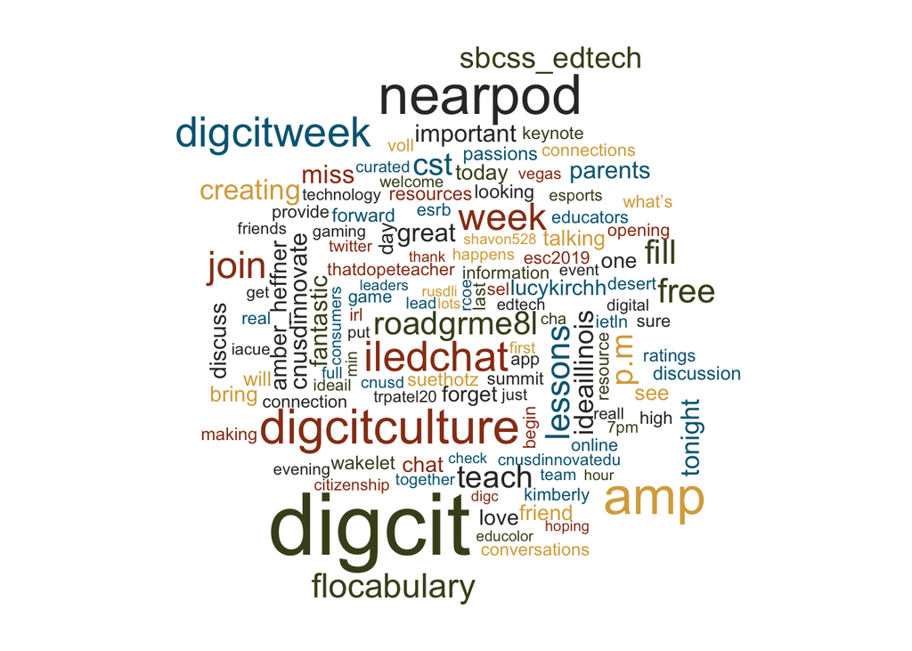

```r
## Transform list of words into a TermDocumentMatrix
cor <- Corpus(VectorSource(tokenList))

tdm <- TermDocumentMatrix(cor)
m <- as.matrix(tdm)
v <- sort(rowSums(m),decreasing=TRUE)
d <- data.frame(word = names(v),freq=v)

## Create the wordcloud
wordcloud(d$word,d$freq, colors=c("#D8AB4C","#006682","#993D1B","#333333","#464E21"), random.color = TRUE, min.freq = 3)
```

### 3. Create transaction data from the tweets and identify 5 rules that are “most interesting”. What criteria did you use to determine whether a rule was “interesting”? Hint: Lift, Support, Confidence, … ?

I then applied `arules` and sorted them by *confidence* and *support*.

```r
## Read in the tweet transactions
TweetTrans <- read.transactions(TransactionTweetsFile,
                                rm.duplicates = FALSE,
                                format = "basket",
                                sep=","
                                ## cols =
                                )
inspect(TweetTrans)
```

[output not shown]

[output cut: 1190 more lines]

```
##        8,
##        cha,
##        cst,
##        digcit,
##        discuss,
##        ideail,
##        ideaillinois,
##        iledchat,
##        important,
##        join,
##        lead,
##        p.m,
##        sure,
##        team,
##        will}
```

```r
## See the words that occur the most
Sample_Trans <- sample(TweetTrans, 50)
summary(Sample_Trans)
```

```
## transactions as itemMatrix in sparse format with
##  50 rows (elements/itemsets/transactions) and
##  333 columns (items) and a density of 0.03723724
##
## most frequent items:
##        digcit digcitculture    digcitweek           amp      iledchat
##            24            12            12            11            11
##       (Other)
##           550
##
## element (itemset/transaction) length distribution:
## sizes
##  8  9 10 11 12 13 14 15 16 18
##  1  3  4 11 10  5  6  7  2  1
##
##    Min. 1st Qu.  Median    Mean 3rd Qu.    Max.
##     8.0    11.0    12.0    12.4    14.0    18.0
##
## includes extended item information - examples:
##   labels
## 1     00
## 2      1
## 3     10
```

```r
## Read the transactions data into a dataframe
TweetDF <- read.csv(TransactionTweetsFile, header = FALSE, sep = ",")
head(TweetDF)
```

```
##                V1      V2                       V3
## 1 thatdopeteacher    love                    y’all
## 2            love   y’all melanatedandtecheducated
## 3         nearpod   teach               digcitweek
## 4        suethotz  digcit                  friends
## 5 cnusdinnovatedu   check            cnusdinnovate
## 6    alhs_library teacher               librarians
##                         V4         V5            V6            V7
## 1 melanatedandtecheducated   educolor        edtech digcitculture
## 2                 educolor     edtech digcitculture         iacue
## 3                  nearpod        amp   flocabulary          free
## 4            cnusdinnovate        put      together     fantastic
## 5                  wakelet collection    digcitweek     resources
## 6          cjuhsdcommunity    getting digcitculture  digcitcommit
##           V8           V9        V10        V11       V12  V13 V14
## 1      iacue          cue pkvuuaxmnd
## 2        cue   pkvuuaxmnd 99roodda1i
## 3    lessons         fill       week roadgrme8l    digcit
## 4    wakelet         full    curated     digcit resources digc
## 5 7acyoa177u           q6        res
## 6   learning sbcss_edtech
```

```r
## Save the dataframe using the write table command
write.table(TweetDF, file = "DigCitCulture.csv", col.names = FALSE, row.names = FALSE, sep = ",")
TweetTrans <- read.transactions("DigCitCulture.csv", sep = ",",
                                format("basket"), rm.duplicates = TRUE)
```

```
## distribution of transactions with duplicates:
## items
##  1  2
## 25  2
```

```r
inspect(TweetTrans)
```

[output not shown]

[output cut: 1195 more lines]

```
##        8,
##        cst,
##        digcit,
##        discuss,
##        ideail,
##        ideaillinois,
##        iledchat,
##        join,
##        p.m,
##        sure,
##        team}
## [120] {cha,
##        important,
##        lead,
##        will}
```

```r
## Apply rules
TweetTrans_rules = arules::apriori(TweetTrans,
                  parameter = list(support=.01, confidence=.01, minlen=2))
```

```
## Apriori
##
## Parameter specification:
##  confidence minval smax arem  aval originalSupport maxtime support minlen
##        0.01    0.1    1 none FALSE            TRUE       5    0.01      2
##  maxlen target   ext
##      10  rules FALSE
##
## Algorithmic control:
##  filter tree heap memopt load sort verbose
##     0.1 TRUE TRUE  FALSE TRUE    2    TRUE
##
## Absolute minimum support count: 1
##
## set item appearances ...[0 item(s)] done [0.00s].
## set transactions ...[338 item(s), 120 transaction(s)] done [0.00s].
## sorting and recoding items ... [180 item(s)] done [0.00s].
## creating transaction tree ... done [0.00s].
## checking subsets of size 1 2 3 4 5 6 7 8 9 10
```

```
##  done [0.06s].
## writing ... [1056400 rule(s)] done [0.21s].
## creating S4 object  ... done [0.94s].
```

```r
inspect(TweetTrans_rules[1:10])
```

```
##      lhs            rhs         support    confidence lift     count
## [1]  {cha}       => {lead}      0.03333333 1.0000000  30.00000 4
## [2]  {lead}      => {cha}       0.03333333 1.0000000  30.00000 4
## [3]  {cha}       => {will}      0.03333333 1.0000000  17.14286 4
## [4]  {will}      => {cha}       0.03333333 0.5714286  17.14286 4
## [5]  {cha}       => {important} 0.03333333 1.0000000  12.00000 4
## [6]  {important} => {cha}       0.03333333 0.4000000  12.00000 4
## [7]  {lead}      => {will}      0.03333333 1.0000000  17.14286 4
## [8]  {will}      => {lead}      0.03333333 0.5714286  17.14286 4
## [9]  {lead}      => {important} 0.03333333 1.0000000  12.00000 4
## [10] {important} => {lead}      0.03333333 0.4000000  12.00000 4
```

```r
## Sort by support
SortedRules_sup <- sort(TweetTrans_rules, by="support", decreasing = TRUE)
inspect(SortedRules_sup[1:15])
```

```
##      lhs              rhs           support   confidence lift     count
## [1]  {amp}         => {digcit}      0.2333333 0.9032258  2.084367 28
## [2]  {digcit}      => {amp}         0.2333333 0.5384615  2.084367 28
## [3]  {iledchat}    => {digcit}      0.1916667 1.0000000  2.307692 23
## [4]  {digcit}      => {iledchat}    0.1916667 0.4423077  2.307692 23
## [5]  {nearpod}     => {fill}        0.1416667 1.0000000  7.058824 17
## [6]  {fill}        => {nearpod}     0.1416667 1.0000000  7.058824 17
## [7]  {nearpod}     => {flocabulary} 0.1416667 1.0000000  7.058824 17
## [8]  {flocabulary} => {nearpod}     0.1416667 1.0000000  7.058824 17
## [9]  {nearpod}     => {lessons}     0.1416667 1.0000000  7.058824 17
## [10] {lessons}     => {nearpod}     0.1416667 1.0000000  7.058824 17
## [11] {nearpod}     => {free}        0.1416667 1.0000000  7.058824 17
## [12] {free}        => {nearpod}     0.1416667 1.0000000  7.058824 17
## [13] {nearpod}     => {week}        0.1416667 1.0000000  6.000000 17
## [14] {week}        => {nearpod}     0.1416667 0.8500000  6.000000 17
## [15] {nearpod}     => {digcitweek}  0.1416667 1.0000000  5.217391 17
```

```r
## Sort by confidence
SortedRules_conf <- sort(TweetTrans_rules, by="confidence", decreasing = TRUE)
inspect(SortedRules_conf[1:15])
```

```
##      lhs               rhs               support    confidence lift
## [1]  {cha}          => {lead}            0.03333333 1          30.00000
## [2]  {lead}         => {cha}             0.03333333 1          30.00000
## [3]  {cha}          => {will}            0.03333333 1          17.14286
## [4]  {cha}          => {important}       0.03333333 1          12.00000
## [5]  {lead}         => {will}            0.03333333 1          17.14286
## [6]  {lead}         => {important}       0.03333333 1          12.00000
## [7]  {teacher}      => {librarians}      0.01666667 1          60.00000
## [8]  {librarians}   => {teacher}         0.01666667 1          60.00000
## [9]  {teacher}      => {learning}        0.01666667 1          60.00000
## [10] {learning}     => {teacher}         0.01666667 1          60.00000
## [11] {teacher}      => {getting}         0.01666667 1          60.00000
## [12] {getting}      => {teacher}         0.01666667 1          60.00000
## [13] {teacher}      => {digcitcommit}    0.01666667 1          60.00000
## [14] {digcitcommit} => {teacher}         0.01666667 1          60.00000
```

[output cut: 17 more lines]

```r
## Sort by lift
SortedRules_lift <- sort(TweetTrans_rules, by="lift", decreasing = TRUE)
inspect(SortedRules_lift[1:15])
```

```
##      lhs                  rhs               support    confidence lift
## [1]  {teacher}         => {librarians}      0.01666667 1          60
## [2]  {librarians}      => {teacher}         0.01666667 1          60
## [3]  {teacher}         => {learning}        0.01666667 1          60
## [4]  {learning}        => {teacher}         0.01666667 1          60
## [5]  {teacher}         => {getting}         0.01666667 1          60
## [6]  {getting}         => {teacher}         0.01666667 1          60
## [7]  {teacher}         => {digcitcommit}    0.01666667 1          60
## [8]  {digcitcommit}    => {teacher}         0.01666667 1          60
## [9]  {teacher}         => {cjuhsdcommunity} 0.01666667 1          60
## [10] {cjuhsdcommunity} => {teacher}         0.01666667 1          60
## [11] {teacher}         => {alhs_library}    0.01666667 1          60
## [12] {alhs_library}    => {teacher}         0.01666667 1          60
## [13] {librarians}      => {learning}        0.01666667 1          60
## [14] {learning}        => {librarians}      0.01666667 1          60
```

[output cut: 17 more lines]

A few examples that stood out as most “interesting” to me were:

1. The support between **amp** and **digcit**. This was interesting because it had the highest support relationship, and I’m not entirely sure what **amp** is referring to. It appeared often, too, with a count of 28.
2. The confidence between **nearpod** and **lessons**. Nearpod is a tool for creating interactive lessons, so I imagine these occurred as a string, to explain the perfect relationship…
3. …However, the perfect confidence between **nearpod** and **flocabulary** is more interesting. Flocabulary is a library of educational hip-hop songs, so it is surprising to see that it also has a perfect confidence of 1.0.

I then created a couple of subsets using `%in%` to include the Twitter handles of a couple colelagues of mine (Sue and Sonal) who presented at the Digital Citizenship Summit

```r
## Subset using @suethotz
sue <- subset(TweetTrans_rules, subset = lhs %in% "suethotz")
SortedSue <- sort(sue, by="count", decreasing = TRUE)
inspect(SortedSue[1:15])
```

```
##      lhs                     rhs             support    confidence
## [1]  {suethotz}           => {fantastic}     0.03333333 0.6666667
## [2]  {suethotz}           => {digcit}        0.03333333 0.6666667
## [3]  {fantastic,suethotz} => {digcit}        0.03333333 1.0000000
## [4]  {digcit,suethotz}    => {fantastic}     0.03333333 1.0000000
## [5]  {suethotz}           => {digc}          0.02500000 0.5000000
## [6]  {suethotz}           => {together}      0.02500000 0.5000000
## [7]  {suethotz}           => {put}           0.02500000 0.5000000
## [8]  {suethotz}           => {full}          0.02500000 0.5000000
## [9]  {suethotz}           => {friends}       0.02500000 0.5000000
## [10] {suethotz}           => {curated}       0.02500000 0.5000000
## [11] {suethotz}           => {resources}     0.02500000 0.5000000
## [12] {suethotz}           => {wakelet}       0.02500000 0.5000000
## [13] {suethotz}           => {cnusdinnovate} 0.02500000 0.5000000
## [14] {digc,suethotz}      => {together}      0.02500000 1.0000000
```

[output cut: 17 more lines]

```r
## Subset using @trpatel20
sonal <- subset(TweetTrans_rules, subset = lhs %in% "trpatel20")
SortedSonal <- sort(sonal, by="count", decreasing = TRUE)
inspect(SortedSonal[1:15])
```

```
##      lhs            rhs             support    confidence lift      count
## [1]  {trpatel20} => {sbcss_edtech}  0.03333333 1.0         8.571429 4
## [2]  {trpatel20} => {inspired}      0.01666667 0.5        30.000000 2
## [3]  {trpatel20} => {new}           0.01666667 0.5        30.000000 2
## [4]  {trpatel20} => {lots}          0.01666667 0.5        20.000000 2
## [5]  {trpatel20} => {leaders}       0.01666667 0.5        20.000000 2
## [6]  {trpatel20} => {hoping}        0.01666667 0.5        20.000000 2
## [7]  {trpatel20} => {event}         0.01666667 0.5        15.000000 2
## [8]  {trpatel20} => {digital}       0.01666667 0.5        15.000000 2
## [9]  {trpatel20} => {citizenship}   0.01666667 0.5        15.000000 2
## [10] {trpatel20} => {get}           0.01666667 0.5        15.000000 2
## [11] {trpatel20} => {technology}    0.01666667 0.5        15.000000 2
## [12] {trpatel20} => {summit}        0.01666667 0.5        12.000000 2
## [13] {trpatel20} => {conversations} 0.01666667 0.5        12.000000 2
## [14] {trpatel20} => {desert}        0.01666667 0.5        12.000000 2
## [15] {trpatel20} => {high}          0.01666667 0.5        12.000000 2
```

A couple interesting findings from this were:

4. There is a 0.67 confidence that “fantastic” appears in a tweet alongside Sue’s Twitter handle.
5. There is a 0.50 confidence that “inspired” appears in a tweet alongside Sonal’s Twitter handle.

### 4. Create a visualization (using arulesviz or another) of the rules found as a result of your ARM model.

Finally, I plotted `SortedRules_sup` and `SortedRules_conf`.

```r
plot(SortedRules_sup[1:50],method = "graph",engine = "interactive",shading = "confidence")
plot(SortedRules_conf[1:50],method = "graph",engine = "interactive",shading = "confidence")
```

[output not shown]